# Week 2 - Getting Real with Regression

Libraries:

```r
library(dplyr)
library(ggplot2)
library(GGally)
```

This chapter analyses a selection of data from a 2014 survey of students participating in an introductory statistics course in Finland. The survey mapped students’ learning approaches and learning achievements. While the original data contained 183 observations of 60 variables, a more limited dataset of 166 observations of 7 variables will be employed here. These variables are the **age** and **gender** of the participants, their **points** from the course representing their performance, their **attitude** towards the course, and three variables mapping their learning styles. These learning styles were the “**surface approach**,” indicating memorization without deeper engagement, “**deep approach**,” indicating an intention to maximize understanding of the subject matter, and “**strategic approach**,” indicating an approach aimed at maximizing the students chance at a good grade. The variables “attitude,” “surface approach,” “deep approach,” and “strategic approach” are all aggregate mean measures of other variables. As such, each variable summarizes related observations into an average. This analysis used the below script, in combination with existing knowledge, to interpret the dataset:

```r
Learn2014 <- read.table("Data/Learn2014", header = TRUE, sep = "\t")
Learn2014$gender <- factor(Learn2014$gender, levels=c("0","1"), labels=c(0,1))
str(Learn2014)
```

```
## 'data.frame':    166 obs. of  7 variables:
##  $ Age   : int  53 55 49 53 49 38 50 37 37 42 ...
##  $ gender: Factor w/ 2 levels "0","1": 2 1 2 1 1 2 1 2 1 2 ...
##  $ attit : num  3.7 3.1 2.5 3.5 3.7 3.8 3.5 2.9 3.8 2.1 ...
##  $ deep  : num  3.58 2.92 3.5 3.5 3.67 ...
##  $ surf  : num  2.58 3.17 2.25 2.25 2.83 ...
##  $ strat : num  3.38 2.75 3.62 3.12 3.62 ...
##  $ Points: int  25 12 24 10 22 21 21 31 24 26 ...
```

The below graphs and summaries of the data help us gain an initial picture of the trends present therein. For one, we can see that a vast majority of students participating in this survey were female (110 v. 56 males), with a mean age of 25 and a half years and approx. 75% of students being below the age of 27.

```r
Graph_AgeGeN <- ggpairs(Learn2014, columns = c(1, 2), legend = 3, title = "Age and Gender", mapping = aes(col = gender), lower = list(combo = wrap("facethist", bins = 20)))

Graph_AgeGenPoints <- ggpairs(Learn2014, columns = c(1,2,7), title = "Effects of Age and Gender on Points", mapping = aes(shape = gender, col = gender), lower = list(combo = wrap("facethist", bins = 20)))

Graph_PredPoints <- ggpairs(Learn2014, columns = c(3:7), title = "Attitude, Study Style and Points", mapping = aes(shape = gender, col = gender), lower = list(combo = wrap("facethist", bins = 20)))
```

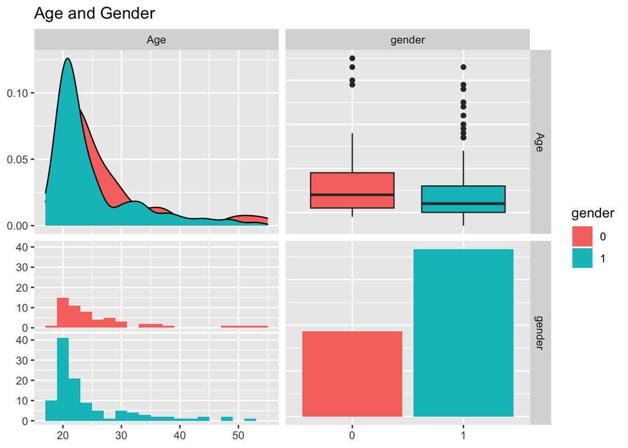

```r
Graph_AgeGeN
```

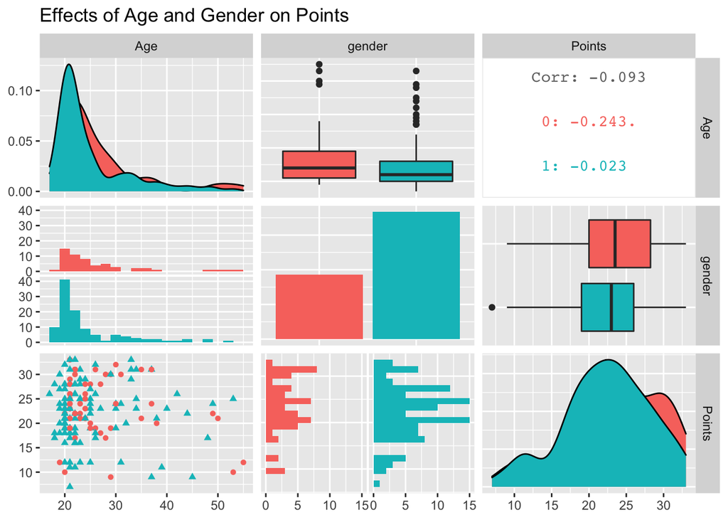

```r
Graph_AgeGenPoints
```

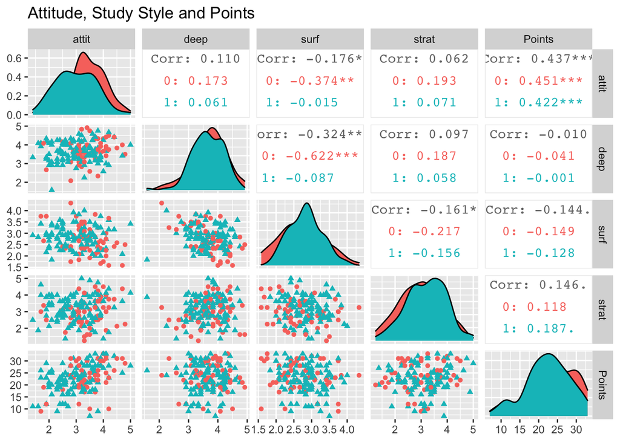

```r
Graph_PredPoints
```

```r
summary(Learn2014)
```

```
##       Age        gender      attit            deep            surf
##  Min.   :17.00   0: 56   Min.   :1.400   Min.   :1.583   Min.   :1.583
##  1st Qu.:21.00   1:110   1st Qu.:2.600   1st Qu.:3.333   1st Qu.:2.417
##  Median :22.00           Median :3.200   Median :3.667   Median :2.833
##  Mean   :25.51           Mean   :3.143   Mean   :3.680   Mean   :2.787
##  3rd Qu.:27.00           3rd Qu.:3.700   3rd Qu.:4.083   3rd Qu.:3.167
##  Max.   :55.00           Max.   :5.000   Max.   :4.917   Max.   :4.333
##      strat           Points
##  Min.   :1.250   Min.   : 7.00
##  1st Qu.:2.625   1st Qu.:19.00
##  Median :3.188   Median :23.00
##  Mean   :3.121   Mean   :22.72
##  3rd Qu.:3.625   3rd Qu.:27.75
##  Max.   :5.000   Max.   :33.00
```

For the below multiple linear regression, three predictor variable have been chosen: Attitude, the surface approach, and the strategic approach. These variables were chosen due to their relatively higher correlations compared to other available variables (age for males is excluded due to the presence of outliers skewing the calculation). The below multiple linear regression shows that only attitude has a statistically significant impact on points, as it is the only independent variable that has its p-value below 0.05. In the case of attitude, there is a less than 0.1 percent chance that the null-hypothesis (attitude has *no* effect on points) is correct under the observed circumstances. Not only is attitude a statistically significant predictor of points, it also seems to have a strong impact, with its beta coefficient being approx. 3.4. This means that with each 1-point step towards a better attitude on the linkert scale, points seem to rise approximately by 3.4.

With the remainder of data, the likelihood is above 5 percent, which is the conventional cut line for statistical significance. This interpretation is also supported by the t-values, which conventionally are expected to be larger than 2, or lesser than -2, to indicate statistical significance. Altogether, this model nevertheless only explain approximately 20% of the variation in points, meaning that is not a very good predictive model.

```r
Points_regression <- lm(Points ~ attit + strat + surf, data = Learn2014)
summary(Points_regression)
```

```
##
## Call:
## lm(formula = Points ~ attit + strat + surf, data = Learn2014)
##
## Residuals:
##      Min       1Q   Median       3Q      Max
## -17.1550  -3.4346   0.5156   3.6401  10.8952
##
## Coefficients:
##             Estimate Std. Error t value Pr(>|t|)
## (Intercept)  11.0171     3.6837   2.991  0.00322 **
## attit         3.3952     0.5741   5.913 1.93e-08 ***
## strat         0.8531     0.5416   1.575  0.11716
## surf         -0.5861     0.8014  -0.731  0.46563
## ---
## Signif. codes:  0 '***' 0.001 '**' 0.01 '*' 0.05 '.' 0.1 ' ' 1
##
## Residual standard error: 5.296 on 162 degrees of freedom
## Multiple R-squared:  0.2074, Adjusted R-squared:  0.1927
## F-statistic: 14.13 on 3 and 162 DF,  p-value: 3.156e-08
```

To further test the significance of attitude, the Surface Approach and Strategic Approach variables will be removed and a simple linear regression carried out with just attitude as the predictor variable. This, nevertheless, produced no novel results and with the dropping of variables, also the explanatory power, Multiple R_squared, of the model has gone down from 0.2 to 0.19. This means that changes in students’ attitude can help explain 19% of the changes in students’ score. The fact that the reduction is so minor is further indication of the minor impact of Surface Approach and Strategic Approach variables. To play around a bit, I have also included a multiple linear regression with age included. Nevertheless, neither this has had any effect on the model. The slight rise in R-squared is to be expected every time a predictive variable is added.

```r
Points_Attit_Reg <- lm(Points ~ attit, data = Learn2014)
summary(Points_Attit_Reg)
```

```
##
## Call:
## lm(formula = Points ~ attit, data = Learn2014)
##
## Residuals:
##      Min       1Q   Median       3Q      Max
## -16.9763  -3.2119   0.4339   4.1534  10.6645
##
## Coefficients:
##             Estimate Std. Error t value Pr(>|t|)
## (Intercept)  11.6372     1.8303   6.358 1.95e-09 ***
## attit         3.5255     0.5674   6.214 4.12e-09 ***
## ---
## Signif. codes:  0 '***' 0.001 '**' 0.01 '*' 0.05 '.' 0.1 ' ' 1
##
## Residual standard error: 5.32 on 164 degrees of freedom
## Multiple R-squared:  0.1906, Adjusted R-squared:  0.1856
## F-statistic: 38.61 on 1 and 164 DF,  p-value: 4.119e-09
```

```r
AgeAttit_Regression <- lm(Points ~ attit + Age, data = Learn2014)
summary(AgeAttit_Regression)
```

```
##
## Call:
## lm(formula = Points ~ attit + Age, data = Learn2014)
##
## Residuals:
##      Min       1Q   Median       3Q      Max
## -17.3354  -3.3095   0.2625   4.0005  10.4911
##
## Coefficients:
##             Estimate Std. Error t value Pr(>|t|)
## (Intercept) 13.57244    2.24943   6.034 1.04e-08 ***
## attit        3.54392    0.56553   6.267 3.17e-09 ***
## Age         -0.07813    0.05315  -1.470    0.144
## ---
## Signif. codes:  0 '***' 0.001 '**' 0.01 '*' 0.05 '.' 0.1 ' ' 1
##
## Residual standard error: 5.301 on 163 degrees of freedom
## Multiple R-squared:  0.2011, Adjusted R-squared:  0.1913
## F-statistic: 20.52 on 2 and 163 DF,  p-value: 1.125e-08
```

To validate the model, this final section will run three plots to test that the assumptions of a regression model are filled by the data. For this validation, the simple linear regression model of Points_Attit_Reg will be used, as it is the most efficient of the models produced. The below graphs “Residuals vs. Fitted,” “Normal Q-Q,” and “Residuals vs. Leverage” test whether the assumptions of normal distribution, non-correlation, and constant variance of errors are met.

The Residuals vs Fitted graph tests the assumption of constant variance of errors by plotting residuals against predicted values. As we can see no discernible pattern in the data, we can interpret the graph as showing no indication of the size of the error depending of the predicted value. Thus constant variance of errors is established

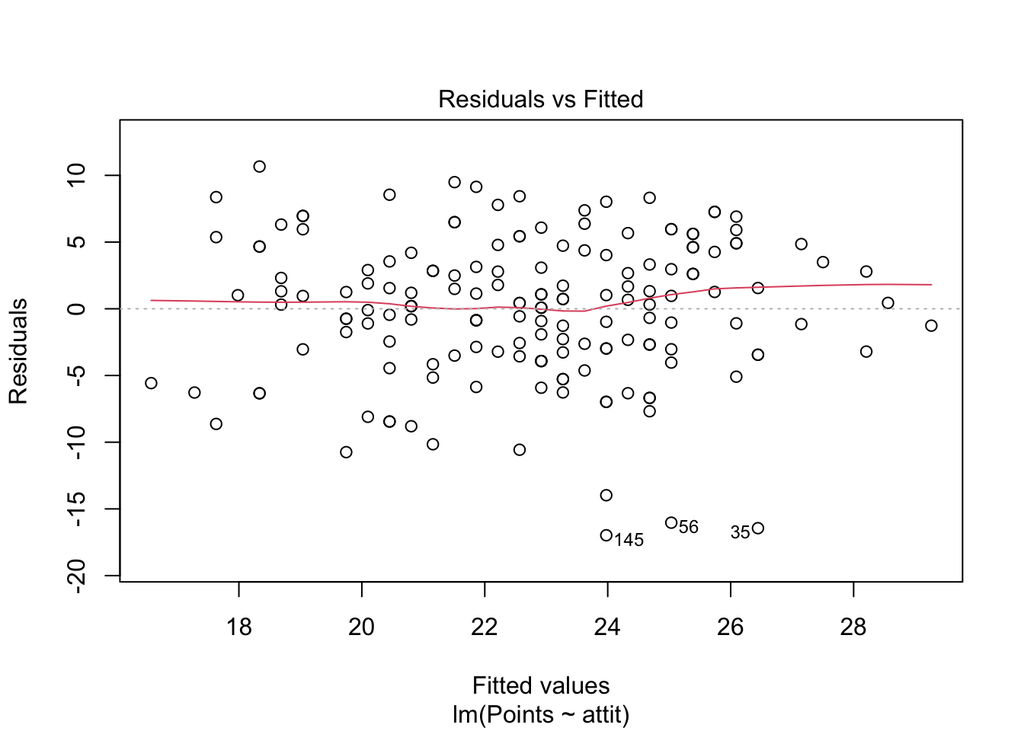

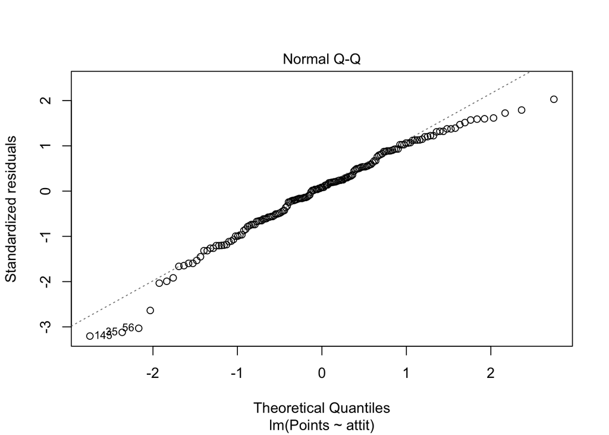

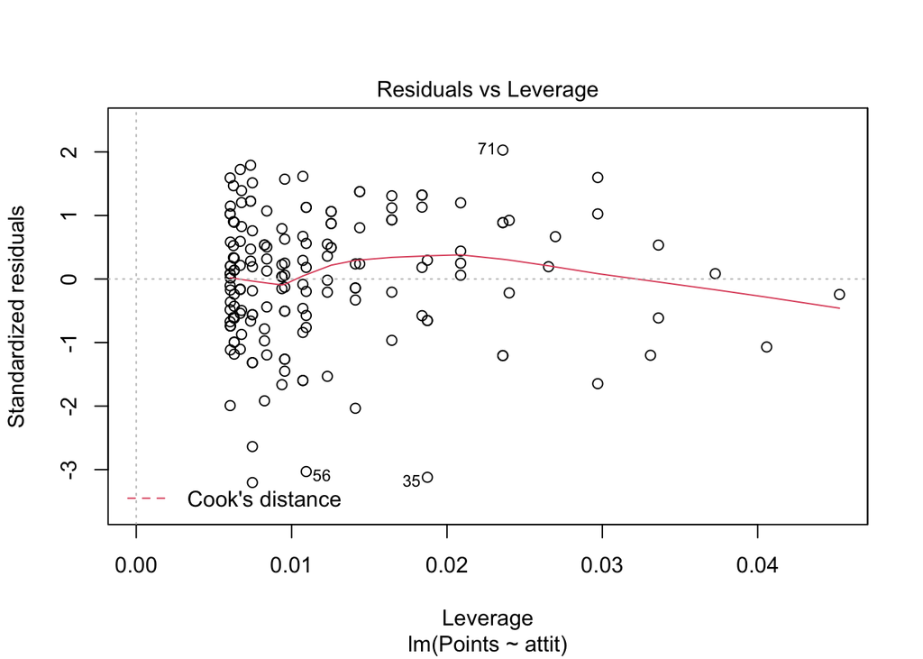

```r
plot(Points_Attit_Reg, which = c(1,2,5))
```